# Summary

2026-01-12

## **Synthetic Sport Datasets**

The literature review identified three main methodological categories for synthetic data generation in sports science which include GAN-based, simulation-based and statistical models.

These three categories describe the primary routes through which synthetic sports data are produced each emphasizing different balances between realism reproducibility and computational complexity.

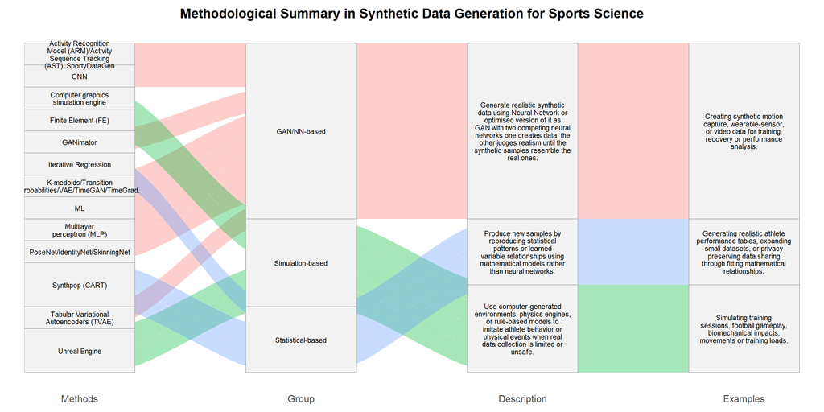

## **Ranking of Real Sport Datasets**

The ranking comparison identifies GAN-based datasets primarily rely on video and image data focused on athlete performance and activity detection, while Statistical datasets encompass tabular, physiological and survey-based data. The evaluation criteria highlights datasets most suitable for each approach, supporting the selection of appropriate data sources for developing synthetic datasets using *Statistical* or *GAN-based* methods.

| **Category** | **Number of Datasets** | **Data Types** | **Population** | **Most Frequent Sports** | **Top 3 (by Score)** |
| --- | --- | --- | --- | --- | --- |
| **GAN-based** | 16 | Video, Image | Athlete | Multiple, Basketball, Fitness | TeamTrack, C-Sports, SportsMOT |
| **Statistical** | 34 | Tabular, Physiological, Medical Record, Survey, Accelerometer | Athlete, Multiple | Football, Baseball, Basketball, Fitness | MTS-5, NCAA-ISP, LLBD |

[interactive chart not shown]

## **Use Cases**

The treemap presents a structured overview of the sport datasets separated into Real and Synthetic sources. Each side groups datasets according to the primary analysis category they support:

- **Movement** focuses on pose estimation, motion tracking, and biomechanical analysis.
- **Tactical** includes formation recognition, event detection, and game-situation analysis.
- **Performance** contains datasets used for fatigue prediction, training-load modelling, and performance monitoring.
- **Player** covers identity tracking, jersey recognition, and technical skill prediction.
- **Injury** groups datasets related to impact simulation, injury risk modelling, and reconstruction of unsafe events.

Each box within a category represents a dataset and contains its key information, including sport, data type, collection method, variables captured, and the specific use case it supports.

[interactive chart not shown]